# HW1 ISYE 6414

Hari Ilangovan

8/25/2019

## Estimated Simple Regression Equation

If we choose the parameters α and β in the [simple linear regression model](http://www.r-tutor.com/node/91) so as to minimize the sum of squares of the error term ϵ, we will have the so called **estimated simple regression equation**. It allows us to compute **fitted values** of y based on values of x.

$\hat{y} = a +bx$

### Problem

Apply the simple linear regression model for the data set [faithful](http://www.r-tutor.com/node/25), and estimate the next eruption duration if the waiting time since the last eruption has been 80 minutes.

### Solution

We apply the lm function to a formula that describes the variable eruptions by the variable waiting, and save the linear regression model in a new variable eruption.lm.

```r
eruption.lm = lm(eruptions ~ waiting, data=faithful)
```

Then we extract the parameters of the estimated regression equation with the coefficients function.

```r
coeffs = coefficients(eruption.lm); coeffs
```

```
## (Intercept)     waiting
## -1.87401599  0.07562795
```

We now fit the eruption duration using the estimated regression equation.

```r
waiting = 80           # the waiting time
duration = coeffs[1] + coeffs[2]*waiting
duration
```

```
## (Intercept)
##     4.17622
```

### Answer

Based on the simple linear regression model, if the waiting time since the last eruption has been 80 minutes, we expect the next one to last 4.1762 minutes.

### Alternative Solution

We wrap the waiting parameter value inside a new [data frame](http://www.r-tutor.com/node/10) named newdata.

```r
newdata = data.frame(waiting=80) # wrap the parameter
```

Then we apply the `predict` function to eruption.lm along with newdata.

```r
predict(eruption.lm, newdata)    # apply predict
```

```
##       1
## 4.17622
```

## Coefficient of Determination

The **coefficient of determination** of a [linear regression model](http://www.r-tutor.com/node/91) is the quotient of the [variances](http://www.r-tutor.com/node/42) of the [fitted values](http://www.r-tutor.com/node/92) and observed values of the dependent variable. If we denote $y_i$ as the observed values of the dependent variable, $\hat{y}$ as its [mean](http://www.r-tutor.com/node/35), and $\hat{y}_i$ as the fitted value, then the coefficient of determination is:

$r^2 = \frac{\sum{(\hat{y_i} - \bar{y})^2}}{\sum{(y_i-\bar{y})^2}}$

### Problem

Find the coefficient of determination for the simple linear regression model of the data set [faithful](http://www.r-tutor.com/node/25).

### Solution

We apply the lm function to a formula that describes the variable eruptions by the variable waiting, and save the linear regression model in a new variable eruption.lm.

```r
eruption.lm = lm(eruptions ~ waiting, data=faithful)
```

Then we extract the coefficient of determination from the r.squared attribute of its summary.

```r
summary(eruption.lm)$r.squared
```

```
## [1] 0.8114608
```

### Answer

The coefficient of determination of the simple linear regression model for the data set `faithful` is 0.81146.

### Note

Further detail of the `r.squared` attribute can be found in the R documentation.

```r
help(summary.lm)
```

## Siginificance Test for Linear Regression

Assume that the error term ϵ in the [linear regression model](http://www.r-tutor.com/node/91) is independent of x, and is [normally distributed](http://www.r-tutor.com/node/58), with zero [mean](http://www.r-tutor.com/node/35) and constant [variance](http://www.r-tutor.com/node/42). We can decide whether there is any **significant relationship** between x and y by testing the null hypothesis that β = 0.

### Problem

Decide whether there is a significant relationship between the variables in the linear regression model of the data set [faithful](http://www.r-tutor.com/node/25) at .05 significance level.

### Solution

We apply the lm function to a formula that describes the variable eruptions by the variable waiting, and save the linear regression model in a new variable eruption.lm.

```r
eruption.lm = lm(eruptions ~ waiting, data=faithful)
```

Then we print out the F-statistics of the significance test with the `summary` function.

```r
summary(eruption.lm)
```

```
##
## Call:
## lm(formula = eruptions ~ waiting, data = faithful)
##
## Residuals:
##      Min       1Q   Median       3Q      Max
## -1.29917 -0.37689  0.03508  0.34909  1.19329
##
## Coefficients:
##              Estimate Std. Error t value Pr(>|t|)
## (Intercept) -1.874016   0.160143  -11.70   <2e-16 ***
## waiting      0.075628   0.002219   34.09   <2e-16 ***
## ---
## Signif. codes:  0 '***' 0.001 '**' 0.01 '*' 0.05 '.' 0.1 ' ' 1
##
## Residual standard error: 0.4965 on 270 degrees of freedom
## Multiple R-squared:  0.8115, Adjusted R-squared:  0.8108
## F-statistic:  1162 on 1 and 270 DF,  p-value: < 2.2e-16
```

### Answer

As the p-value is much less than 0.05, we reject the null hypothesis that β = 0. Hence there is a significant relationship between the variables in the linear regression model of the data set `faithful`.

### Note

Further detail of the summary function for linear regression model can be found in the R documentation.

```r
help(summary.lm)
```

## Confidence Interval for Linear Regression

Assume that the error term ϵ in the [linear regression model](http://www.r-tutor.com/node/91) is independent of $x$, and is [normally distributed](http://www.r-tutor.com/node/58), with zero [mean](http://www.r-tutor.com/node/35) and constant [variance](http://www.r-tutor.com/node/42). For a given value of $x$, the interval estimate for the mean of the dependent variable, $\bar{y}$ , is called the **confidence interval**.

### Problem

In the data set [faithful](http://www.r-tutor.com/node/25), develop a 95% confidence interval of the mean eruption duration for the waiting time of 80 minutes.

### Solution

We apply the `lm` function to a formula that describes the variable eruptions by the variable waiting, and save the linear regression model in a new variable `eruption.lm`.

```r
# using the attach function errors the knit/render of R Markdown#
# ommitted attach(faithful)
eruption.lm = lm(eruptions ~ waiting, data=faithful)
```

Then we create a new [data frame](http://www.r-tutor.com/node/10) that set the waiting time value.

```r
newdata = data.frame(waiting=80)
```

We now apply the `predict` function and set the predictor variable in the `newdata` argument. We also set the interval type as `"confidence"`, and use the default 0.95 confidence level.

```r
predict(eruption.lm, newdata, interval="confidence")
```

```
##       fit      lwr      upr
## 1 4.17622 4.104848 4.247592
```

### Answer

The 95% confidence interval of the mean eruption duration for the waiting time of 80 minutes is between 4.1048 and 4.2476 minutes.

### Note

Further detail of the `predict` function for linear regression model can be found in the R documentation.

```r
help(predict.lm)
```

## Prediction Interval for Linear Regression

Assume that the error term ϵ in the [simple linear regression model](http://www.r-tutor.com/node/91) is independent of $x$, and is [normally distributed](http://www.r-tutor.com/node/58), with zero [mean](http://www.r-tutor.com/node/35) and constant [variance](http://www.r-tutor.com/node/42). For a given value of $x$, the interval estimate of the dependent variable $y$ is called the **prediction interval**.

### Problem

In the data set [faithful](http://www.r-tutor.com/node/25), develop a 95% prediction interval of the eruption duration for the waiting time of 80 minutes.

### Solution

We apply the `lm` function to a formula that describes the variable `eruptions` by the variable `waiting`, and save the linear regression model in a new variable `eruption.lm`.

```r
# using the attach function errors the knit/render of R Markdown#
# ommitted attach(faithful)
eruption.lm = lm(eruptions ~ waiting, data=faithful)
```

Then we create a new [data frame](http://www.r-tutor.com/node/10) that set the waiting time value.

```r
newdata = data.frame(waiting=80)
```

We now apply the `predict` function and set the predictor variable in the `newdata` argument. We also set the interval type as `"predict"`, and use the default 0.95 confidence level.

```r
predict(eruption.lm, newdata, interval="predict")
```

```
##       fit      lwr      upr
## 1 4.17622 3.196089 5.156351
```

### Answer

The 95% prediction interval of the eruption duration for the waiting time of 80 minutes is between 3.1961 and 5.1564 minutes.

### Note

Further detail of the predict function for linear regression model can be found in the R documentation.

```r
help(predict.lm)
```

## Residual Plot

The **residual** data of the [simple linear regression model](http://www.r-tutor.com/node/91) is the difference between the observed data of the dependent variable y and the [fitted values](http://www.r-tutor.com/node/92) $\hat{y}$.

$Residual = y - \hat{y}$

### Problem

Plot the residual of the simple linear regression model of the data set [faithful](http://www.r-tutor.com/node/25) against the independent variable `waiting`.

### Solution

We apply the `lm` function to a formula that describes the variable `eruptions` by the variable `waiting`, and save the linear regression model in a new variable `eruption.lm`. Then we compute the residual with the `resid` function.

```r
eruption.lm = lm(eruptions ~ waiting, data=faithful)
eruption.res = resid(eruption.lm)
```

We now plot the residual against the observed values of the variable `waiting`.

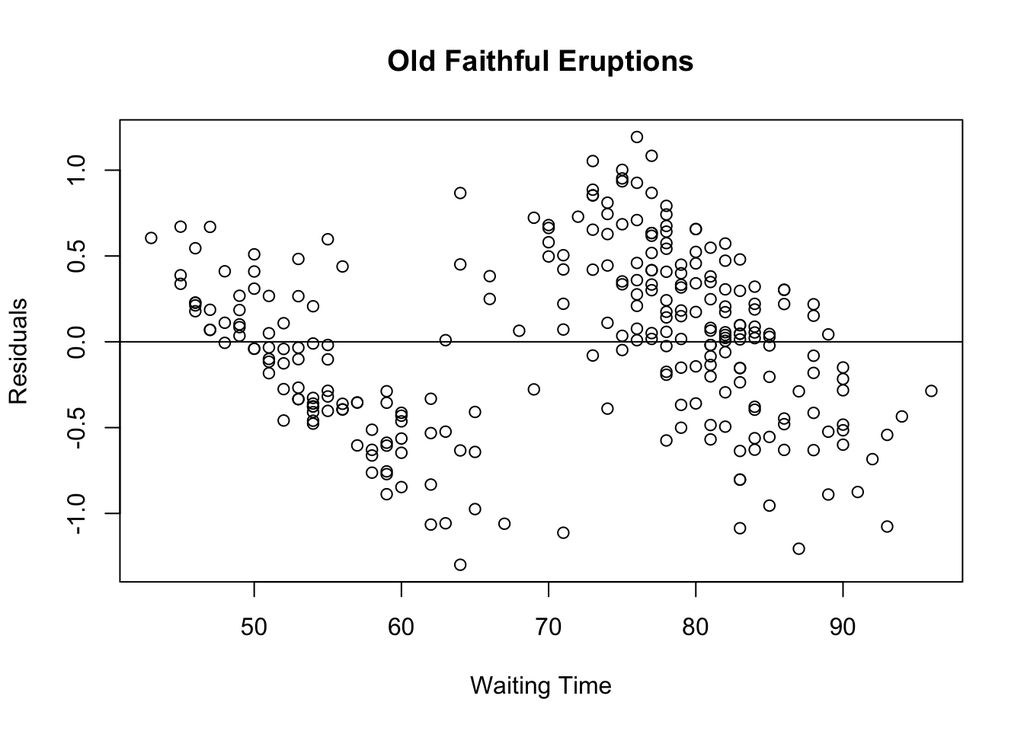

```r
plot(faithful$waiting, eruption.res, ylab="Residuals", xlab="Waiting Time", main="Old Faithful Eruptions")
abline(0, 0)        # the horizon
```

### Note

Further detail of the `resid` function can be found in the R documentation.

```r
help(resid)
```

## Standardized Residual

The **standardized residual** is the [residual](http://www.r-tutor.com/node/97) divided by its [standard deviation](http://www.r-tutor.com/node/43).

$Standardized Residual i = \frac{Residual\:i}{Standard\,Deviation\,of\, Residual\:i}$

### Problem

Plot the standardized residual of the simple linear regression model of the data set [faithful](http://www.r-tutor.com/node/25) against the independent variable `waiting`.

### Solution

We apply the `lm` function to a formula that describes the variable `eruptions` by the variable `waiting`, and save the linear regression model in a new variable `eruption.lm`. Then we compute the standardized residual with the `rstandard` function.

```r
eruption.lm = lm(eruptions ~ waiting, data=faithful)
eruption.stdres = rstandard(eruption.lm)
```

We now plot the standardized residual against the observed values of the variable `waiting`.

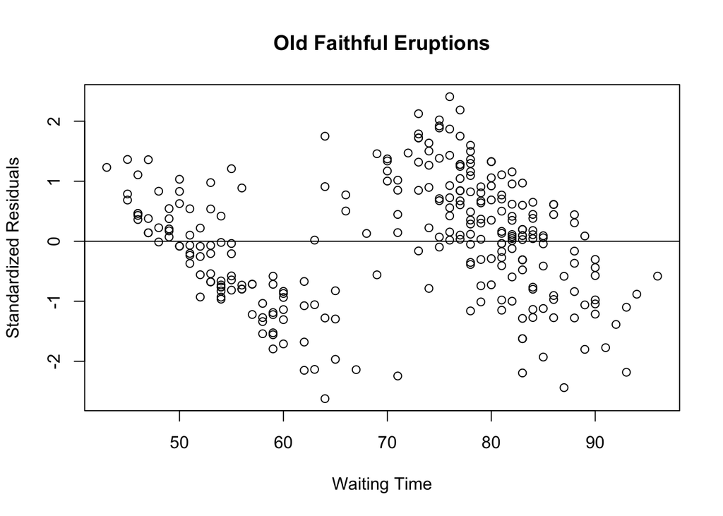

```r
plot(faithful$waiting, eruption.stdres, ylab="Standardized Residuals", xlab="Waiting Time", main="Old Faithful Eruptions")
abline(0, 0)                  # the horizon
```

### Note

Further detail of the `rstandard` function can be found in the R documentation.

```r
help(rstandard)
```

## Normal Probability Plot of Residuals

The **normal probability plot** is a graphical tool for comparing a data set with the [normal distribution](http://www.r-tutor.com/node/58). We can use it with the [standardized residual](http://www.r-tutor.com/node/98) of the [linear regression model](http://www.r-tutor.com/node/91) and see if the error term ϵ is actually normally distributed.

### Problem

Create the normal probability plot for the standardized residual of the data set [faithful](http://www.r-tutor.com/node/25).

### Solution

We apply the `lm` function to a formula that describes the variable eruptions by the variable `waiting`, and save the linear regression model in a new variable `eruption.lm`. Then we compute the standardized residual with the `rstandard` function.

```r
eruption.lm = lm(eruptions ~ waiting, data=faithful)
eruption.stdres = rstandard(eruption.lm)
```

We now create the normal probability plot with the `qqnorm` function, and add the `qqline` for further comparison.

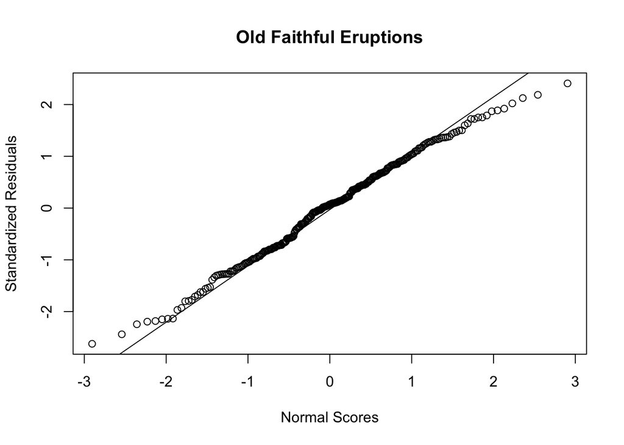

```r
qqnorm(eruption.stdres, ylab="Standardized Residuals", xlab="Normal Scores", main="Old Faithful Eruptions")
qqline(eruption.stdres)
```

### Note

Further detail of the `qqnorm` and `qqline` functions can be found in the R documentation.

```r
help(qqnorm)
```

## SLR1

For the eruption.lm model, what are the estimated coefficients and what is the estimated regression equation?

### Response

In the eruption.lm model, the estimated coefficients $\hat{\beta}_0$ and $\hat\beta_0$ are identified through the following function call to the fitted linear regression model:

```r
coeff = coefficients(eruption.lm)
alpha = coeff[1]; alpha
```

```
## (Intercept)
##   -1.874016
```

```r
beta = coeff[2]; beta
```

```
##    waiting
## 0.07562795
```

Thus, the value of the estimated $\hat{\beta_0}$ is -1.874016 and the estimated $\hat{\beta_1}$ is 0.0756279.

The estimated regression equation is $\hat{y} = -1.874016 + 0.07562795x$

## SLR2

Interpret the coefficients of $\beta_0$ and $\beta_1$ in the context of the problem.

### Response

The context of the eruption problem is a model of the response variable $(y)$, which is the duration of eruption based off the predicting variable $(x)$, which is the waiting time since the last eruption.

The estimated parameter $\hat\beta_0$ (intercept) of -1.874016 does not make physical sense in this context because it is proposing a negative eruption duration when the waiting time between eruptions is 0.

## SLR3

Derive the 95% and 99% confidence intervals for the slope coefficient. Compare the confidence intervals in terms of reliability and accuracy. Interpret with respect to the statistical significance of the coefficient.

### Response

```r
int99 <- confint(eruption.lm, level=0.99)
print("The 99% confidence interval for the lm model")
```

```
## [1] "The 99% confidence interval for the lm model"
```

```r
int99
```

```
##                  0.5 %     99.5 %
## (Intercept) -2.2894534 -1.4585785
## waiting      0.0698727  0.0813832
```

```r
int95 <- confint(eruption.lm, level = 0.95)
print("The 95% confidence interval for the lm model")
```

```
## [1] "The 95% confidence interval for the lm model"
```

```r
int95
```

```
##                   2.5 %      97.5 %
## (Intercept) -2.18930436 -1.55872761
## waiting      0.07126011  0.07999579
```

The difference between the upper and lower bounds is greater for the 99% confidence interval than compared to the 95% confidence interval. From a reliability perspective, the larger margin for the 99% is explained by the tradeoff between accuracy and reliability. The more reliable we want our estimation, the higher the confidence interval, and the larger the range in possible values.

## SLR4

What is the correction coefficient between the response and the predicting variables? How does the correlation coefficient compare to the R squared?

### Response

```r
sqrt(0.8115)
```

```
## [1] 0.9008329
```

The correlation coefficient $\rho$ between the response and predicting variables is 0.9 based on the calculation shown above. The positive value near 1 indicates a direct relationship (positive correlation) between the response and predicting variable. The correlation coefficient compares to the $R^2$ value of 0.8115 by showing that the fitted positively correlated ($\rho = 0.9$) relationship accounts for ~81% of the total variance in the response variable.

## SLR5

What would the model predict for a waiting time of 65, a 99% significance level with an interval = “prediction”? Interpret.

```r
newdata = data.frame(waiting=65)
predict(eruption.lm, newdata, interval="predict", level = 0.99)
```

```
##        fit      lwr      upr
## 1 3.041801 1.750955 4.332647
```

The model predicts an eruption duration time of 3.04 with a lower bound of 1.75 and upper bound of 4.33. The range between the upper and lower bound of the predicted value is high with respect to the fitted value. To be exact the range is $\pm 42.4$% of the predicted fitted value. This is due to the high confidence interval and additional variance from the inclusion of an additional observation for prediction.

## SLR6

Interpret the output of the QQ Normal plot (above) against the Normality assumption.

### Response

The QQ Normal plot shows a linear relationship that is close to the 45 degrees (qqline) overlayed on the plot for the majority of the points central in the data set. However, the left and right tails of the QQ normal plot curve away from the qqline indicated non-normality. However, since most of the points in the data set are bound closely to the qqline, the variance is approximately normal.

## SLR7

Interpret the Standardized Residuals plot (above) against the Constant Variance assumption.

## SLR8

Interpret the Standardized Residuals plot (above) against the Independence assumption

### Response

The standardizard residuals plot shows clusters of residuals between waiting times of 40 - 60 and 70 - 90. These clusters are showing a non-random pattern that could indicate a dependent relationship between the residuals and the predicting variable `waiting` time. Thus, the independence assumption does not hold.

## SLR9

Create a scatterplot of the two variables

### Response

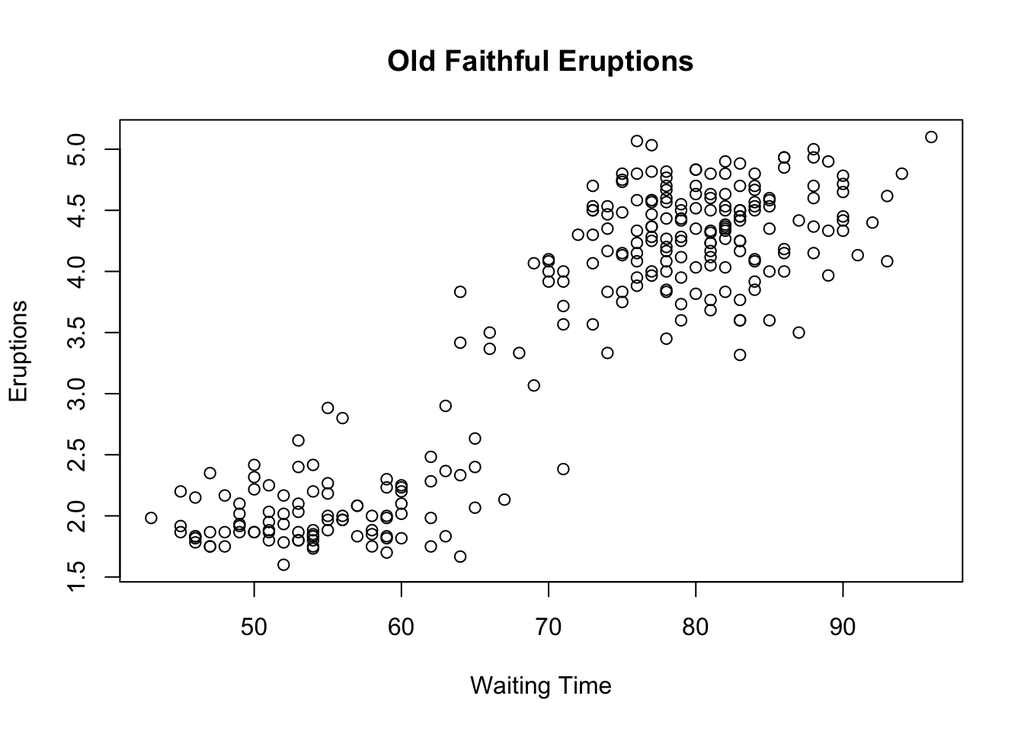

The Waiting time versus the Eruption Time

```r
plot(faithful$waiting, faithful$eruptions, ylab="Eruptions", xlab="Waiting Time", main="Old Faithful Eruptions")
```

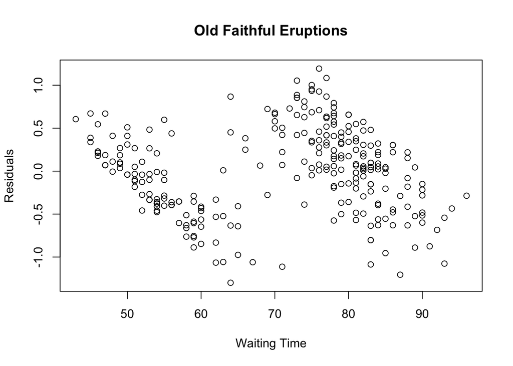

The Waiting time versus the Residuals

```r
plot(faithful$waiting, resid(eruption.lm), ylab="Residuals", xlab="Waiting Time", main="Old Faithful Eruptions")
```

## SLR10

Interpret the scatterplot against the Linearity assumption

### Response

The plot of the predicting variable (`waiting`) against the response variable (`eruptions`) indicates a linear relationship since the response variable seems to increase as the predicting variable increases. This indicates a direct relationship between the predicting and response variables.